# Demonstration of Data Wrangling Methods

Anton Prokopyev, 2017

## Background Information

Image an online service or an app that collects user data. Below I demonstrate what can be done with its data in terms of data manipulation and analysis.

Let’s load libraries and data. Two faux csv files have been created to imitate data collected:

```r
rm(list = ls(all.names = TRUE))

# Specify the packages of interest
packages = c("reshape2", "ggplot2", "dplyr", "gridExtra", "cowplot")

# Use this function to check if each package is on the local machine
# if a package is installed, it will be loaded
# if any are not, the missing package(s) will be installed and loaded
package.check <- lapply(packages, FUN = function(x) {
    if (!require(x, character.only = TRUE)) {
        install.packages(x, dependencies = TRUE)
        library(x, character.only = TRUE, quietly = TRUE)
    }
})
setwd("/Users/MacBookAir/Desktop/GoogleDrive/DATA/R/r-data-wrangling/")
visits <- read.table("visits.csv", sep=",", header=T)
signups <- read.table("signups.csv", sep=",", header=T)
```

Signups.csv: 1) Uid. A unique user ID (primary key) 2) Auth_type. 3 ways users sign up for the service: A, B, or C. 3) Device. Types of devices used to sign up. It has values from 1 – 7, each depicting a device type (eg. MacBook, iOS, Android, etc.) 4) Signup_dt. Signup date

```r
head(signups)
```

```
##   X      uid  signup_dt auth_type device
## 1 1 21639492 2016-06-01         C      1
## 2 2 21640161 2016-06-01         A      6
## 3 3 21640773 2016-06-01         C      5
## 4 4 21641605 2016-06-01         A      1
## 5 5 21643130 2016-06-01         C      6
## 6 6 21644509 2016-06-01         C      1
```

Visits.csv: 1) Uid. A unique user ID 2) Dt. Date when the user visited the imaginary website/app

```r
head(visits)
```

```
##   X      uid         dt
## 1 1 21655745 2016-11-11
## 2 2 22635182 2016-11-02
## 3 3 22361195 2016-07-24
## 4 4 22132291 2017-03-19
## 5 5 22639754 2017-02-15
## 6 6 22998116 2016-09-06
```

Convert dates to years and months. We don’t need days here:

```r
visits$year <- as.numeric(format(as.Date(visits$dt, format="%Y-%m-%d"),"%Y"))
visits$month <- as.numeric(format(as.Date(visits$dt, format="%Y-%m-%d"),"%m"))
signups$year <- as.numeric(format(as.Date(signups$signup_dt, format="%Y-%m-%d"),"%Y"))
signups$month <- as.numeric(format(as.Date(signups$signup_dt, format="%Y-%m-%d"),"%m"))
```

Let’s treat 4 months in 2017 as 13, 14, 15, 16 months of 2016. For simplicity:

```r
visits$monthNum <- visits$month + (visits$year == 2017) * 12
```

## DEMO 1

Let’s show the frequency distribution of users by different devices, auth types, and their combinations.

Here I create bar charts with frequencies (fractions) for signups, by devices, and by auth types.

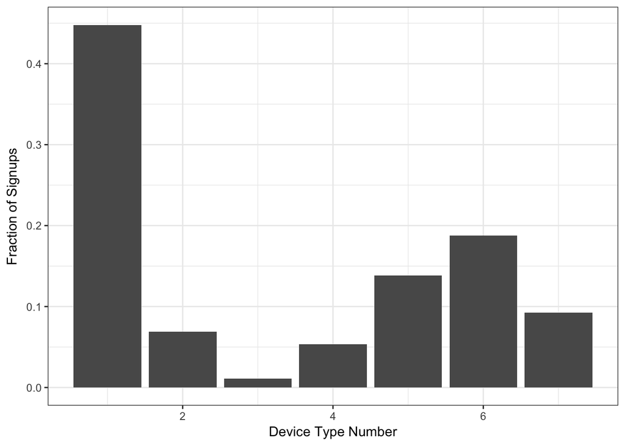

```r
g1 <- ggplot(signups, aes(x=device)) +
  geom_bar(aes(y = (..count..)/sum(..count..))) +
  xlab("Device Type Number") +
  ylab("Fraction of Signups") +
  theme_bw()
g1
```

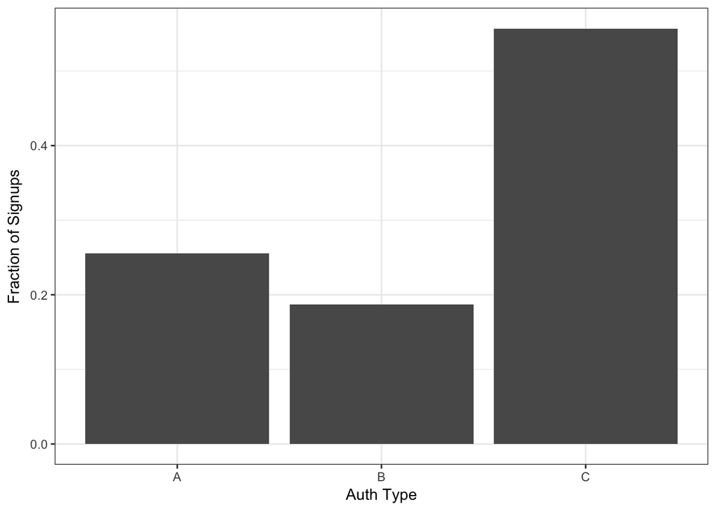

```r
g2 <- ggplot(signups, aes(x=auth_type)) +
  geom_bar(aes(y = (..count..)/sum(..count..))) +
  xlab("Auth Type") +
  ylab("Fraction of Signups") +
  theme_bw()
g2
```

I also render a combined plot for device and auth_type combined:

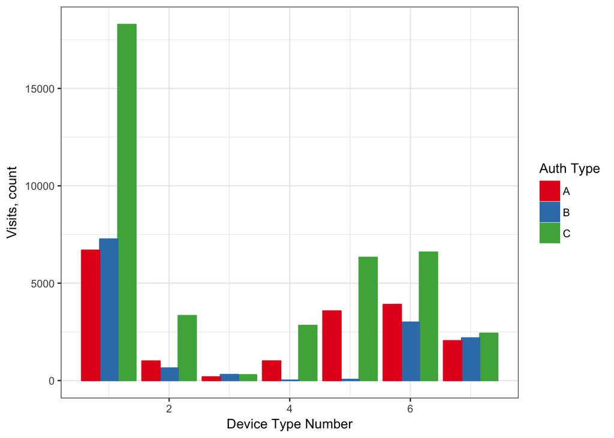

```r
two <- table(signups$device, signups$auth_type)
two.melt <- melt(two)

colnames(two.melt) <- c("device", "auth_type", "count")
g3 <- ggplot(two.melt) +
  geom_bar(aes(x=device,y=count, color=auth_type, fill=auth_type),stat="identity", position = "dodge") +
  xlab("Device Type Number") +
  ylab("Visits, count") +
  theme_bw() +
  scale_color_brewer(palette="Set1") +
  scale_fill_brewer(palette="Set1") +
  guides(fill=guide_legend(title="Auth Type")) +
  guides(color=guide_legend(title="Auth Type"))
g3
```

## DEMO 2

Let’s see, for example, what % of users visited the app at least once 3 months later after they signed up? Let’s limit this to users who signed up in Jul 2016.

Consider all the users who signed up in July to be part of the July cohort, and 3 months later is anyone who visited anytime in October 2016.

Assuming this doesn’t have to be exactly 90 days apart. This monthly cohort assumption is used below as well.

Let’s first subset users that signed up in July 2016. Among them we will count users that returned in October. Their ids will be saved in ‘fOct’:

```r
signups.July16 <- filter(signups, year==2016, month==7)
fOct <- unique(filter(visits, year==2016, month==10)[,"uid"])
length(unique(filter(signups.July16, uid %in% fOct)[,"uid"]))/length(unique(signups.July16$uid))
```

```
## [1] 0.4174461
```

## DEMO 3

Let’s make this a little more complicated. Take users who signed up in August 2016. I will show what proportion of them visited at least once in each of the months, 1, 2, 3, 4, and 5 months later. E.g. if you signed up in August 2016, and visited once in September 2016, you will be counted as someone who visited in the 1st month. If you visit again in November 2016, you will be counted as someone who visited at least once in the 3rd month.

We will compare these stats against someone who signed up in September 2016.

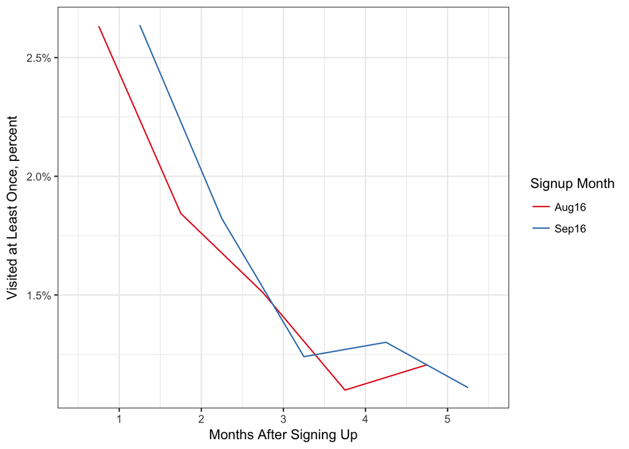

```r
signups.Aug16 <- filter(signups, year==2016, month==8)
visits.aggr.Aug16 <-
  visits %>%
  filter(monthNum %in% c(9,10,11,12,13)) %>%
  filter(uid %in% signups.Aug16$uid) %>%
  group_by(uid) %>%
  # filter(as.Date(dt) == max(as.Date(dt))) %>%
  mutate(distLatest = monthNum - 8)
t.Aug16 <- table(visits.aggr.Aug16$distLatest)/length(unique(signups.Aug16$uid))

visits.aggr.Aug16_2 <-
  visits %>%
  filter(monthNum %in% c(9,10,11,12,13)) %>%
  filter(uid %in% signups.Aug16$uid) %>% group_by(uid)
  # filter(as.Date(dt) == max(as.Date(dt))) %>%
  # mutate(distLatest = monthNum - 8)


signups.Sep16 <- filter(signups, year==2016, month==9)
visits.aggr.Sep16 <- visits %>%
  filter(monthNum %in% c(10,11,12,13,14)) %>%
  filter(uid %in% signups.Sep16$uid) %>%
  group_by(uid) %>%
  # filter(as.Date(dt) == max(as.Date(dt))) %>%
  mutate(distLatest = monthNum - 9)
t.Sep16 <- table(visits.aggr.Sep16$distLatest)/length(unique(signups.Sep16$uid))

t <- cbind(t.Aug16, t.Sep16)
colnames(t) <- c("Aug16","Sep16")

tMelted <- melt(t)
colnames(tMelted) <- c("month", "signedUp", "percent")
tMelted$percent <- tMelted$percent/100

ggplot(tMelted) +
  geom_line(aes(x=month,
                y=percent,
                color=signedUp),
            stat="identity",
            position = position_dodge(width = 1)) +
  theme_bw() +
  scale_y_continuous(labels = scales::percent) +
  scale_color_brewer(palette="Set1") +
  scale_fill_brewer(palette="Set1") +
  guides(fill=guide_legend(title="Signup Month")) +
  guides(color=guide_legend(title="Signup Month")) +
  xlab("Months After Signing Up") +
  ylab("Visited at Least Once, percent")
```

The plots look similar. Let’s add auth type:

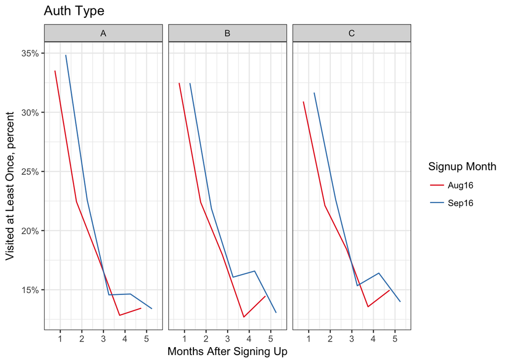

```r
visits.aggr.Aug16.merged <- merge(visits.aggr.Aug16, signups.Aug16, by.x="uid", by.y="uid")
visits.aggr.Sep16.merged <- merge(visits.aggr.Sep16, signups.Sep16, by.x="uid", by.y="uid")

t.Aug.auth <- table(visits.aggr.Aug16.merged$distLatest, visits.aggr.Aug16.merged$auth_type)
t.Sep.auth <- table(visits.aggr.Sep16.merged$distLatest, visits.aggr.Sep16.merged$auth_type)

tab.A <- cbind(t.Aug.auth[,1]/sum(t.Aug.auth[,1]), t.Sep.auth[,1]/sum(t.Sep.auth[,1]))
colnames(tab.A) <- c("Aug16","Sep16")
tab.A.Melted <- melt(tab.A)
tab.A.Melted$auth <- "A"

tab.B <- cbind(t.Aug.auth[,2]/sum(t.Aug.auth[,2]), t.Sep.auth[,2]/sum(t.Sep.auth[,2]))
colnames(tab.B) <- c("Aug16","Sep16")
tab.B.Melted <- melt(tab.B)
tab.B.Melted$auth <- "B"

tab.C <- cbind(t.Aug.auth[,3]/sum(t.Aug.auth[,3]), t.Sep.auth[,3]/sum(t.Sep.auth[,3]))
colnames(tab.C) <- c("Aug16","Sep16")
tab.C.Melted <- melt(tab.C)
tab.C.Melted$auth <- "C"

tab.final <- rbind(tab.A.Melted, tab.B.Melted, tab.C.Melted)

colnames(tab.final) <- c("month", "signedUp", "percent", "auth")

ggplot(tab.final) +
  geom_line(aes(x=month,
                y=percent,
                color=signedUp),
            stat="identity",
            position = position_dodge(width = 1)) +
  theme_bw() +
  scale_y_continuous(labels = scales::percent) +
  scale_color_brewer(palette="Set1") +
  scale_fill_brewer(palette="Set1") +
  xlab("Months After Signing Up") +
  ylab("Visited at Least Once, percent") +
  guides(fill=guide_legend(title="Signup Month")) +
  guides(color=guide_legend(title="Signup Month")) +
  ggtitle("Auth Type") +
  facet_grid(~auth)
```

## DEMO 4

Let’s examine users who signed up in June 2016. We’ll see what proportion of them came back at least once within 1 month, once within 2 months, etc. all the way to at least once within 6 months. E.g. if you signed up in June 2016 and visited in September 2016, you would be counted as someone who came back at least once within 3 months. By definition, you would also be counted as someone who came back within 4, 5 and 6 months.

Below is a graphical representation of this.

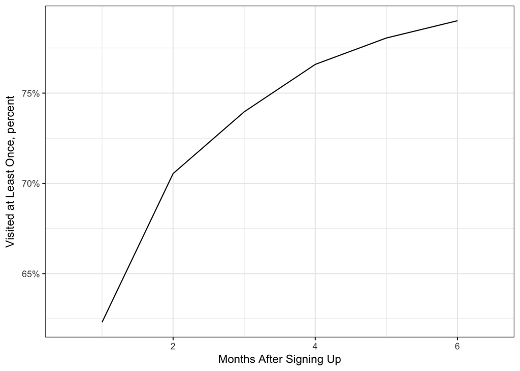

```r
signups.June16 <- filter(signups, year==2016, month==6)

visits.June16 <- visits %>%
  filter(uid %in% signups.June16$uid)

SliceVisits <- function(visits, num) {
  visits.June16.sliced <- visits.June16 %>%
   filter(monthNum %in% c(7:num)) %>%
   group_by(uid) %>%
    filter(row_number(uid) == 1)
  return((dim(visits.June16.sliced)[1])/length(unique(signups.June16$uid)))
}

result <- rep(0,6)

for (i in c(1:6)) {
  result[i] <- SliceVisits(visits, 6+i)
}

result.df <- cbind(c(1:6), result)

colnames(result.df) <- c("monthsAfter", "percent")

result.df <- data.frame(result.df)

ggplot(result.df) +
  geom_line(aes(x=monthsAfter,y=percent),
            stat="identity",
            position = position_dodge(width = 1),
            ) +
  theme_bw() +
  scale_y_continuous(labels = scales::percent) +
  xlab("Months After Signing Up") +
  ylab("Visited at Least Once, percent")
```

We are witnessing reassuring statistics that in a matter of 6 months almost 80% of users who signed up for the service come back at least once.

Here is the proportion of the users who never came back after signing up:

```r
1 - SliceVisits(visits, 16)
```

```
## [1] 0.1846381
```